# Višestruka linearna regresija

> U ovoj svesci ispitujemo svojstva i mogućnosti modeliranja pomoću linearne regresije sa većim brojem nezavisno promenljivih veličina.

Linearna regresija je model koji pretpostavlja linearnu zavisnost između jedne nezavisne ($x$) i jedne zavisne promenljive ($y$). Tako, na primer, cenu stana možemo da procenimo na osnovu njegove kvadrature. Međutim, stan ne karakteriše samo površina, tu je važno i u kom je kraju grada, koliko je stara zgrada, da li ima svoj parking itd. Kada bismo imali sve ove podatke, bilo bi dobro da ih sve uključimo kao nezavisne promenljive ($x_1, x_2, x_3...$) koje u svojoj linearnoj kombinaciji daju procenu cene stana. Naravno, u pitanju je procena i neizbežno je da postoji greška ($\epsilon$) koju ne možemo da procenimo. Možemo samo da se potrudimo da bude što manja. Zadatak višestruke linearne regresije je da odredi optimalne parametre linearne funkcije ($\beta_1, \beta_2, \beta_3...$).

$$ y = \beta_0 + \beta_1x_1 + \beta_2x_2 + \beta_3x_3 + \epsilon $$

Svaka nova informacija bi, ako imamo dovoljno veliki skup podataka, trebalo da popravi procenu. Situacija u praksi, ipak nije tako jednostavna. Što je veći broj nezavisno promenljivih potreban nam je veći skup podatka. Takođe, uvek ima nekih nepotrebnih i redundatnih promeljivih koje nije lako uočiti. Zato je, pre nego što uključimo u lineranu regresiju sve moguće promenjive, potrebno da obratimo pažnju na sledeće dve stvari:

- Povećanje broja promenljivih u linearnoj regresiji nije uvek korisno. Zapravo, rizikujemo da podaci za obuku previše dobro fituju (*over-fit*), a da procene kod podataka za testiranje budu loše. Tada će formula za predikciju biti previše složena za dobijeni kvalitet procene. Bolje je da skup nezavisnih promenljivih bude manji, ali dobro odabran.
- Promenjive nisu potpuno nezavisne jedna od druge. Velika zavisnost između dve ili više promenljivih kvari procenu parametara linearne funkcije. Ova okolnost se naziva multikolinearnost promenljivih (*multicollinearity*). Potrebno je da je uvek imamo i vidu i da smanjimo njene efekte.

Linearna regresija je postojala, naravno, mnogo pre mašinskog učenja. Zbog svoje jednostavnosti, danas je to njegov osnovni i najčešće korišćeni model.

Za ilustraciju višestruke linearne regresije koristićemo podatke o karakteristima i cenama kuća sa sajta [Kaggle.com](https://www.kaggle.com/ashydv/housing-dataset). Preuzeti skup podataka se se zove **Housing.csv** nalazi se u folderu **data**.

Na početku ćemo učitati sve neophodne biblioteke.

```python
import pandas as pd
import numpy as np
import matplotlib.pyplot as plt
%matplotlib inline
import seaborn as sns
```

```python
housing = pd.read_csv('data/Housing.csv')
```

Strukturu podataka možemo da vidimo pomoću funkcije `info()`.

```python
housing.info()
```

```
<class 'pandas.core.frame.DataFrame'>
RangeIndex: 545 entries, 0 to 544
Data columns (total 13 columns):
 #   Column            Non-Null Count  Dtype
---  ------            --------------  -----
 0   price             545 non-null    int64
 1   area              545 non-null    int64
 2   bedrooms          545 non-null    int64
 3   bathrooms         545 non-null    int64
 4   stories           545 non-null    int64
 5   mainroad          545 non-null    object
 6   guestroom         545 non-null    object
 7   basement          545 non-null    object
 8   hotwaterheating   545 non-null    object
 9   airconditioning   545 non-null    object
 10  parking           545 non-null    int64
 11  prefarea          545 non-null    object
 12  furnishingstatus  545 non-null    object
dtypes: int64(6), object(7)
memory usage: 55.5+ KB
```

Vidimo da tabele ima nekoliko numeričkih promenljivih: cena (u dolarima), površina (u kvadratnim stopama), broj spavaćih soba, broj kupatila, broj spratova i broj parking mesta. Osim njih, tu su i neke kategorijalne promenljive.

```python
housing
```

|  | price | area | bedrooms | bathrooms | stories | mainroad | guestroom | basement | hotwaterheating | airconditioning | parking | prefarea | furnishingstatus |
| --- | --- | --- | --- | --- | --- | --- | --- | --- | --- | --- | --- | --- | --- |
| 0 | 13300000 | 7420 | 4 | 2 | 3 | yes | no | no | no | yes | 2 | yes | furnished |
| 1 | 12250000 | 8960 | 4 | 4 | 4 | yes | no | no | no | yes | 3 | no | furnished |
| 2 | 12250000 | 9960 | 3 | 2 | 2 | yes | no | yes | no | no | 2 | yes | semi-furnished |
| 3 | 12215000 | 7500 | 4 | 2 | 2 | yes | no | yes | no | yes | 3 | yes | furnished |
| 4 | 11410000 | 7420 | 4 | 1 | 2 | yes | yes | yes | no | yes | 2 | no | furnished |
| ... | ... | ... | ... | ... | ... | ... | ... | ... | ... | ... | ... | ... | ... |
| 540 | 1820000 | 3000 | 2 | 1 | 1 | yes | no | yes | no | no | 2 | no | unfurnished |
| 541 | 1767150 | 2400 | 3 | 1 | 1 | no | no | no | no | no | 0 | no | semi-furnished |
| 542 | 1750000 | 3620 | 2 | 1 | 1 | yes | no | no | no | no | 0 | no | unfurnished |
| 543 | 1750000 | 2910 | 3 | 1 | 1 | no | no | no | no | no | 0 | no | furnished |
| 544 | 1750000 | 3850 | 3 | 1 | 2 | yes | no | no | no | no | 0 | no | unfurnished |

545 rows × 13 columns

Sem tabelarnog načina za prikazivanje podataka, zgodno je napraviti i grafički prikaz raspodele pojedinačnih promenljivih i njihove međusobne zavisnosti. To nam daje dobar uvid u sadržaj skupa podataka i međusobni odnos promenljivih. Za to možemo da koristimo funkciju `pairplot()` iz biblioteke **seaborn**. Dovoljno je da naziv tabele stavimo kao argument pomenute funkcije.

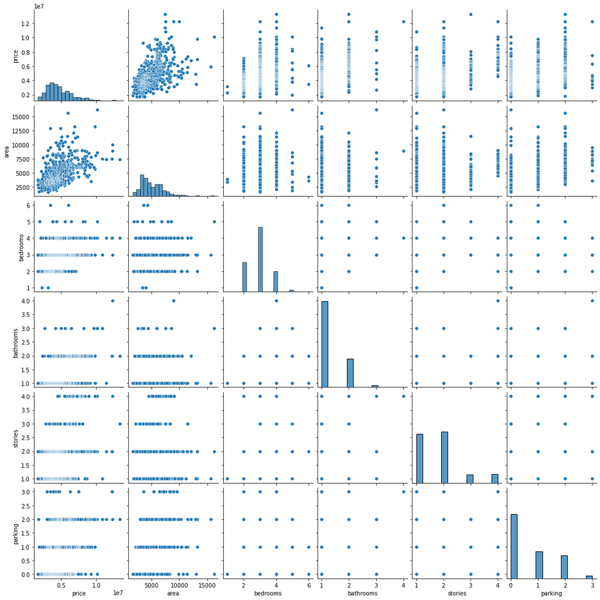

```python
sns.pairplot(housing)
```

Vidimo da, sem cene i površine, sve druge promenljive imaju mali broj diskretnih vredosti. Takođe, vidi se da na grafikonu nema kategorijalnih promenljivih. Funkcija `pairplot()` radi samo sa numeričkim kolonama.

Prva kolona sadrži podatke o ceni kuća. Cena je zavisna promenljiva koju pokušavamo da procenimo na osnovu ostalih promenljivih. Kasnije ćemo ove podatke razdvojiti.

Pre nego što pređemo na višestruku linearnu regresiju da vidimo šta bi nam dala "jednostruka", odnosno obična zavisnost jedne zavisne i jedne nezavisne promenljive. To bi bila zavisnost cene od (verovatno) najvažnije nezavisno promenljive (površina kuće). Kako izgleda ta zavisnost možemo da vidimo na grafiku koji dobijamo pomoću funkcije `scatterplot()`.

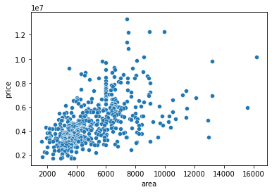

```python
sns.scatterplot(x='area',y='price',data=housing)
```

Podaci su prilično rasejani i ova zavisnost ne omogućava preciznu procenu cene. Uz pomoć funkcije `corr()` možemo da odredimo koeficijent korelacije između ove dve promenljive. Koeficijent korelacije ćemo korsititi kao meru rastura podataka i mogućnosti za preciznu predikciju cene.

```python
housing[['price','area']].corr()
```

|  | price | area |
| --- | --- | --- |
| price | 1.000000 | 0.535997 |
| area | 0.535997 | 1.000000 |

Koeficijent korelacije između samo jedne nezavisno promenljive i cene je 0.536. Videćemo da li će posle uvođenja drugih promenljivih korelacija biti bolja.

## Priprema kategorijalnih podataka

Da bismo iskoristili kategorijalne podatke moramo nekako da ih prevedemo u numeričke. Ukoliko su to binarne vrednosti ('da' i 'ne'), onda lako možemo da ih pretvorimo u 0 i 1. Promenljiva **furnishingstatus** nije binarna pa ćemo je za sad ostaviti po strani. Prvo ćemo ove binarne izdvojiti u listu **kateg**.

```python
# pretvaranje kategorijalnih vrednosti u numeričke
kateg =  ['mainroad', 'guestroom', 'basement', 'hotwaterheating', 'airconditioning', 'prefarea']
```

Za mapiranje iz yes u 1 i no u 0, treba da napišemo funkciju.

```python
def binary_map(x):
    return x.map({'yes': 1, "no": 0})
```

Sada ćemo funkciju `binary_map()` primeniti na sve kolone čija su imena sadržana u listi **kateg** uz pomoć funkcije `apply()`.

```python
housing[kateg] = housing[kateg].apply(binary_map)
```

Da vidimo kako sad izgleda tabela **housing**.

```python
housing
```

|  | price | area | bedrooms | bathrooms | stories | mainroad | guestroom | basement | hotwaterheating | airconditioning | parking | prefarea | furnishingstatus |
| --- | --- | --- | --- | --- | --- | --- | --- | --- | --- | --- | --- | --- | --- |
| 0 | 13300000 | 7420 | 4 | 2 | 3 | 1 | 0 | 0 | 0 | 1 | 2 | 1 | furnished |
| 1 | 12250000 | 8960 | 4 | 4 | 4 | 1 | 0 | 0 | 0 | 1 | 3 | 0 | furnished |
| 2 | 12250000 | 9960 | 3 | 2 | 2 | 1 | 0 | 1 | 0 | 0 | 2 | 1 | semi-furnished |
| 3 | 12215000 | 7500 | 4 | 2 | 2 | 1 | 0 | 1 | 0 | 1 | 3 | 1 | furnished |
| 4 | 11410000 | 7420 | 4 | 1 | 2 | 1 | 1 | 1 | 0 | 1 | 2 | 0 | furnished |
| ... | ... | ... | ... | ... | ... | ... | ... | ... | ... | ... | ... | ... | ... |
| 540 | 1820000 | 3000 | 2 | 1 | 1 | 1 | 0 | 1 | 0 | 0 | 2 | 0 | unfurnished |
| 541 | 1767150 | 2400 | 3 | 1 | 1 | 0 | 0 | 0 | 0 | 0 | 0 | 0 | semi-furnished |
| 542 | 1750000 | 3620 | 2 | 1 | 1 | 1 | 0 | 0 | 0 | 0 | 0 | 0 | unfurnished |
| 543 | 1750000 | 2910 | 3 | 1 | 1 | 0 | 0 | 0 | 0 | 0 | 0 | 0 | furnished |
| 544 | 1750000 | 3850 | 3 | 1 | 2 | 1 | 0 | 0 | 0 | 0 | 0 | 0 | unfurnished |

545 rows × 13 columns

Sve su vrednosti numeričke osim za poslednju kolonu gde imamo tri moguće vrednosti: **furnished**, **semi_furnished** i **unfurnished**. U ovakvim slučajevima se konstruišu tri fiktivne promenljive (*dummy variables*) za svaku moguću vrednost. One su binarne i samo nam daju podatak da li je na tom mestu u tabeli prva vrednost (0/1), druga (0/1) ili treća (0/1). Pošto vrednost mora biti jedna od ove tri, onda su tri promenljive previše. Ako znamo dve, očigledno je koja je treća. Npr. ako su **furnished**=0 i **semi_furnished**=0, onda mora biti da je **unfurnished**=1. Vrlo je važno da eliminišemo tu jednu promenljivu viška zbog efekta kolinearnosti. U opštem slučaju, ako imamo $n$ vrednosti, onda konstruišemo $n-1$ fiktivnu promenljivu.

Za konstruisanje fiktivnih promenljivih koristimo funkciju `get_dummies()` biblioteke **pandas**. Odmah ćemo izbrisati prvu kolonu, **furnished**.

```python
dummy = pd.get_dummies(housing['furnishingstatus'], drop_first = True)
```

```python
dummy
```

|  | semi-furnished | unfurnished |
| --- | --- | --- |
| 0 | 0 | 0 |
| 1 | 0 | 0 |
| 2 | 1 | 0 |
| 3 | 0 | 0 |
| 4 | 0 | 0 |
| ... | ... | ... |
| 540 | 0 | 1 |
| 541 | 1 | 0 |
| 542 | 0 | 1 |
| 543 | 0 | 0 |
| 544 | 0 | 1 |

545 rows × 2 columns

Tabelom **dummy** ćemo proširiti tabelu **housing** pomoću funkcije `concat()`. Nakon toga ćemo izbrisati kategorijalnu promenljivu **furnishingstatus** koja nam više nije potrebna.

```python
housing = pd.concat([housing, dummy], axis = 1)
housing.drop(['furnishingstatus'], axis = 1, inplace = True)
```

```python
housing
```

|  | price | area | bedrooms | bathrooms | stories | mainroad | guestroom | basement | hotwaterheating | airconditioning | parking | prefarea | semi-furnished | unfurnished |
| --- | --- | --- | --- | --- | --- | --- | --- | --- | --- | --- | --- | --- | --- | --- |
| 0 | 13300000 | 7420 | 4 | 2 | 3 | 1 | 0 | 0 | 0 | 1 | 2 | 1 | 0 | 0 |
| 1 | 12250000 | 8960 | 4 | 4 | 4 | 1 | 0 | 0 | 0 | 1 | 3 | 0 | 0 | 0 |
| 2 | 12250000 | 9960 | 3 | 2 | 2 | 1 | 0 | 1 | 0 | 0 | 2 | 1 | 1 | 0 |
| 3 | 12215000 | 7500 | 4 | 2 | 2 | 1 | 0 | 1 | 0 | 1 | 3 | 1 | 0 | 0 |
| 4 | 11410000 | 7420 | 4 | 1 | 2 | 1 | 1 | 1 | 0 | 1 | 2 | 0 | 0 | 0 |
| ... | ... | ... | ... | ... | ... | ... | ... | ... | ... | ... | ... | ... | ... | ... |
| 540 | 1820000 | 3000 | 2 | 1 | 1 | 1 | 0 | 1 | 0 | 0 | 2 | 0 | 0 | 1 |
| 541 | 1767150 | 2400 | 3 | 1 | 1 | 0 | 0 | 0 | 0 | 0 | 0 | 0 | 1 | 0 |
| 542 | 1750000 | 3620 | 2 | 1 | 1 | 1 | 0 | 0 | 0 | 0 | 0 | 0 | 0 | 1 |
| 543 | 1750000 | 2910 | 3 | 1 | 1 | 0 | 0 | 0 | 0 | 0 | 0 | 0 | 0 | 0 |
| 544 | 1750000 | 3850 | 3 | 1 | 2 | 1 | 0 | 0 | 0 | 0 | 0 | 0 | 0 | 1 |

545 rows × 14 columns

Sada, pošto su nam sve promenljive numeričke, možemo da vidimo kakve su im međusobne zavisnosti. Izračunaćemo koeficijent korelacije za svaki par promenljivih pomoću funkcije `corr()`.

```python
housing.corr()
```

|  | price | area | bedrooms | bathrooms | stories | mainroad | guestroom | basement | hotwaterheating | airconditioning | parking | prefarea | semi-furnished | unfurnished |
| --- | --- | --- | --- | --- | --- | --- | --- | --- | --- | --- | --- | --- | --- | --- |
| price | 1.000000 | 0.535997 | 0.366494 | 0.517545 | 0.420712 | 0.296898 | 0.255517 | 0.187057 | 0.093073 | 0.452954 | 0.384394 | 0.329777 | 0.063656 | -0.280587 |
| area | 0.535997 | 1.000000 | 0.151858 | 0.193820 | 0.083996 | 0.288874 | 0.140297 | 0.047417 | -0.009229 | 0.222393 | 0.352980 | 0.234779 | 0.006156 | -0.142278 |
| bedrooms | 0.366494 | 0.151858 | 1.000000 | 0.373930 | 0.408564 | -0.012033 | 0.080549 | 0.097312 | 0.046049 | 0.160603 | 0.139270 | 0.079023 | 0.050040 | -0.126252 |
| bathrooms | 0.517545 | 0.193820 | 0.373930 | 1.000000 | 0.326165 | 0.042398 | 0.126469 | 0.102106 | 0.067159 | 0.186915 | 0.177496 | 0.063472 | 0.029834 | -0.132107 |
| stories | 0.420712 | 0.083996 | 0.408564 | 0.326165 | 1.000000 | 0.121706 | 0.043538 | -0.172394 | 0.018847 | 0.293602 | 0.045547 | 0.044425 | -0.003648 | -0.082972 |
| mainroad | 0.296898 | 0.288874 | -0.012033 | 0.042398 | 0.121706 | 1.000000 | 0.092337 | 0.044002 | -0.011781 | 0.105423 | 0.204433 | 0.199876 | 0.011450 | -0.133123 |
| guestroom | 0.255517 | 0.140297 | 0.080549 | 0.126469 | 0.043538 | 0.092337 | 1.000000 | 0.372066 | -0.010308 | 0.138179 | 0.037466 | 0.160897 | 0.005821 | -0.099023 |
| basement | 0.187057 | 0.047417 | 0.097312 | 0.102106 | -0.172394 | 0.044002 | 0.372066 | 1.000000 | 0.004385 | 0.047341 | 0.051497 | 0.228083 | 0.050284 | -0.117935 |
| hotwaterheating | 0.093073 | -0.009229 | 0.046049 | 0.067159 | 0.018847 | -0.011781 | -0.010308 | 0.004385 | 1.000000 | -0.130023 | 0.067864 | -0.059411 | 0.063819 | -0.059194 |
| airconditioning | 0.452954 | 0.222393 | 0.160603 | 0.186915 | 0.293602 | 0.105423 | 0.138179 | 0.047341 | -0.130023 | 1.000000 | 0.159173 | 0.117382 | -0.053179 | -0.094086 |
| parking | 0.384394 | 0.352980 | 0.139270 | 0.177496 | 0.045547 | 0.204433 | 0.037466 | 0.051497 | 0.067864 | 0.159173 | 1.000000 | 0.091627 | 0.041327 | -0.165705 |
| prefarea | 0.329777 | 0.234779 | 0.079023 | 0.063472 | 0.044425 | 0.199876 | 0.160897 | 0.228083 | -0.059411 | 0.117382 | 0.091627 | 1.000000 | -0.011535 | -0.081271 |
| semi-furnished | 0.063656 | 0.006156 | 0.050040 | 0.029834 | -0.003648 | 0.011450 | 0.005821 | 0.050284 | 0.063819 | -0.053179 | 0.041327 | -0.011535 | 1.000000 | -0.588405 |
| unfurnished | -0.280587 | -0.142278 | -0.126252 | -0.132107 | -0.082972 | -0.133123 | -0.099023 | -0.117935 | -0.059194 | -0.094086 | -0.165705 | -0.081271 | -0.588405 | 1.000000 |

Cena kuće najviše zavisi od kvadrature (r=0.536), ali zavisi i od broj kupatila (r=0.518) i broja spratova (r=0.421) i toga da li ima klimu (r=0.453). Pošto je cena promenjliva koju hoćemo da procenimo, dobro je da imamo dobru korealiciju nezavisnih promenljivih sa njom. Ono što nam ne treba jeste da te promenljive međusobno dobro koreliraju. Vidimo, na primer, da broj parking mesta dobro korelira sa površinom kuće (r=0.353). To bi moglo da bude znak da nam jedna od njih nije potrebna.

## Skaliranje

Da bismo mogli da poredimo doprinose pojedinih ulaznih promenljivih proceni izlazne, poželjno je da one budu na istoj skali. Vidimo da površina kuće ide od 1650 do 16200 kvadratnih stopa, dok broj parking mesta ide od 0 do 3. Ako su obe promenljive podjednako značajne, onda će regresioni koeficijent uz površinu biti hiljadama puta manji nego onaj uz broj parking mesta. Zato je zgodno da sve promenljive skaliramo tako da minimalna vrednost bude nula, a maksimalna jedan. Onda će nam koeficijenti biti uporedivi i biće jasnije koja je promenljiva koliko važna za predikciju.

```python
promzask = ['area', 'bedrooms', 'bathrooms', 'stories', 'parking'] # uzimamo samo promenljive koje već nisu od 0 do 1
for i in promzask:
    m=min(housing[i])
    M=max(housing[i])
    housing[i]=(housing[i]-m)/(M-m)
```

```python
housing
```

|  | price | area | bedrooms | bathrooms | stories | mainroad | guestroom | basement | hotwaterheating | airconditioning | parking | prefarea | semi-furnished | unfurnished |
| --- | --- | --- | --- | --- | --- | --- | --- | --- | --- | --- | --- | --- | --- | --- |
| 0 | 13300000 | 0.396564 | 0.6 | 0.333333 | 0.666667 | 1 | 0 | 0 | 0 | 1 | 0.666667 | 1 | 0 | 0 |
| 1 | 12250000 | 0.502405 | 0.6 | 1.000000 | 1.000000 | 1 | 0 | 0 | 0 | 1 | 1.000000 | 0 | 0 | 0 |
| 2 | 12250000 | 0.571134 | 0.4 | 0.333333 | 0.333333 | 1 | 0 | 1 | 0 | 0 | 0.666667 | 1 | 1 | 0 |
| 3 | 12215000 | 0.402062 | 0.6 | 0.333333 | 0.333333 | 1 | 0 | 1 | 0 | 1 | 1.000000 | 1 | 0 | 0 |
| 4 | 11410000 | 0.396564 | 0.6 | 0.000000 | 0.333333 | 1 | 1 | 1 | 0 | 1 | 0.666667 | 0 | 0 | 0 |
| ... | ... | ... | ... | ... | ... | ... | ... | ... | ... | ... | ... | ... | ... | ... |
| 540 | 1820000 | 0.092784 | 0.2 | 0.000000 | 0.000000 | 1 | 0 | 1 | 0 | 0 | 0.666667 | 0 | 0 | 1 |
| 541 | 1767150 | 0.051546 | 0.4 | 0.000000 | 0.000000 | 0 | 0 | 0 | 0 | 0 | 0.000000 | 0 | 1 | 0 |
| 542 | 1750000 | 0.135395 | 0.2 | 0.000000 | 0.000000 | 1 | 0 | 0 | 0 | 0 | 0.000000 | 0 | 0 | 1 |
| 543 | 1750000 | 0.086598 | 0.4 | 0.000000 | 0.000000 | 0 | 0 | 0 | 0 | 0 | 0.000000 | 0 | 0 | 0 |
| 544 | 1750000 | 0.151203 | 0.4 | 0.000000 | 0.333333 | 1 | 0 | 0 | 0 | 0 | 0.000000 | 0 | 0 | 1 |

545 rows × 14 columns

## Obučavanje linearnog modela

Da bismo obučili bilo koji model mašinskog učenja, potrebno je da razdvojimo ulazne (označićemo ih sa x) i izlazne promenljive (y). U našem slučaju samo je cena kuće izlazna, sve ostale su ulazne. Mi ćemo, konkretno, podeliti tabelu **housing** na dva dela: x i z.

```python
x = housing.drop('price',axis=1)
y = housing['price']
```

Pri obučavanju modela u mašinskom učenju, odnosno određivanju parametara linearne funkcije, uvek prvo treba podeliti skup podataka na deo za obuku ili trening (train) i deo za testiranje (test). Jedino tako ćemo znati koliko dobru predikciju daje naš model. Biblioteka **scikit-learn** ima funkciju `train_test_split()` koja slučajnim izborom deli podatke i ulaznih i izlaznih promenljivih u odnosu koji zadamo. Obično se za testiranje uzina 20-30% ukupnog uzorka.

```python
from sklearn.model_selection import train_test_split
```

```python
x_train, x_test, y_train, y_test = train_test_split(x, y, test_size = 0.3)
```

Sada možemo da pređemo na samu obuku modela. Konkretan model je predstavljen funkcijom `LinearRegression()` u biblioteci **sklearn.linear_model**. Korišćenjem ove funkcije konstruisuaćemo objekat **model** koji će sadržati sve podatke i funkcije za linearnu regresiju nad prethodno pripremljenim podacima.

```python
from sklearn.linear_model import LinearRegression

model = LinearRegression()
```

Za obuku modela koristimo funkciju `fit()`. Argumenti su ulazni i izlazni skup podataka za obučavanje.

```python
model.fit(x_train, y_train)
```

```
LinearRegression()
```

Sad je model obučen što znači da su svi koeficijenti linearne regresije određeni. Njih možemo da prikažemo kao atribut **coef_** objekta **model**, odnosno `model_coef_`.

```python
print(model.coef_)
```

```
[3931467.52201903  336877.85598979 3456858.11219889 1310025.14244244
  323197.77457327  278633.78369001  367477.93609942  869291.47824898
  812079.70550991  852928.90234881  599889.55091916   80653.23281898
 -312364.62483493]
```

Slično, možemo da prikažemo i slobodni član ($\beta_0$ iz opšte formule za linearnu regresiju).

```python
print(model.intercept_)
```

```
2006425.6280832142
```

Iste ove koeficijente možemo da prikažemo preglednije kao *DataFrame*.

```python
pd.DataFrame(model.coef_, x.columns, columns = ['Coeff'])
```

|  | Coeff |
| --- | --- |
| area | 3.931468e+06 |
| bedrooms | 3.368779e+05 |
| bathrooms | 3.456858e+06 |
| stories | 1.310025e+06 |
| mainroad | 3.231978e+05 |
| guestroom | 2.786338e+05 |
| basement | 3.674779e+05 |
| hotwaterheating | 8.692915e+05 |
| airconditioning | 8.120797e+05 |
| parking | 8.529289e+05 |
| prefarea | 5.998896e+05 |
| semi-furnished | 8.065323e+04 |
| unfurnished | -3.123646e+05 |

Sada po prvi put vidimo pojedinačne koeficijente pridružene nazivima promenljivih pa sada možemo da vidimo koliki je čiji doprinos konačnoj proceni. Najznačajnije promenljive su površina, broj kupatila i broj spratova, dok najmanju ulogu igra podatak koji kaže da je stan polunamenšten (_semi*furnished*).

Koristeći novodobijene koeficijente možemo da izračunamo procenu cene kuće za bilo koje vrednosti promenljivih. To znači da sada možemo da iskoristimo podatke za testiranje koje smo ostavili po strani (**x_test**) i da vidimo šta model predviđa za izlazne vrednosti, odnosno kako procenjuje cenu kuća.

```python
procena = model.predict(x_test)
```

Ovu procenu možemo da uporedimo sa sačuvanim izlaznim podacima iz tabele (y_test). Jedan od načina je da ih grafički prikažemo kao tačkasti dijagram.

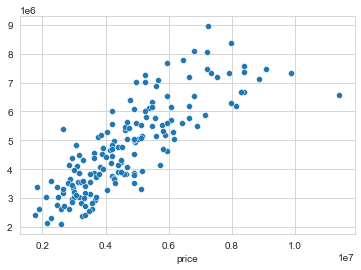

```python
sns.set_style('whitegrid')
sns.scatterplot(x=y_test, y=procena);
```

Ako uporedite ovaj grafik sa onim prvim u svesci gde smo koristili procenu samo na osnovu površine kuće, primetićete da je ovde slaganje nešto bolje. Verovatno će to potvrditi i koeficijent korelacije.

```python
np.corrcoef(y_test,procena)[0,1]
```

```
0.8203132181615034
```

Nesumnjivo, bolja je procena na osnovu svih dostupnih karakteristika kuće nego samo na osnovu površine. Ipak, greška procene nije mala.

```python
np.std(y_test - procena)
```

```
1000262.3675297563
```

Standarna devijacija razlike cene i procene je nešto više od milion dolara. Deluje mnogo, ali s obzirom da su cene ovih kuća po nekoliko miliona možda to i nije previše. Trebalo bi pitati eksperta iz trgovine nekretninama u SAD da nam protumači ovaj podatak.

Razliku između procena i stvarnih cena kuća možemo da vizuelizujemo koristeći histogram razlika ove dve vrednosti. Razlike procene i stvarne vrednosti se zovu rezuduali. Zbog toga se često ovakvi grafici nazivaju histogrami reziduala.

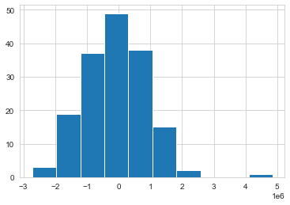

```python
plt.hist(y_test - procena);
```

Ako histogram reziduala prikazuje normalnu raspodelu to znači da smo izabrali adekvatan model.

## Završni komentari

Višestruka linearna regresija je, po svemu sudeći, bila dobar izbor modela mašinskog učenja. Bolje je kad za isti objekat imamo više karakteristika i sve njih možemo da koristimo kao prediktore.

Problem je što možda koristimo previše različitih karakteristika. Manji broj promenljivih bi smanjio količinu podataka koju obrađujemo, ubrzao procenu koeficijenata, učinio da koeficijenti budu pouzdaniji, a verovatno i da procena bude bolja. Izabrati optimalan skup promenljivih za predikciju (*feature selection*) nije jednostavan zadatak. On zahteva da znamo pouzdanost svakog procenjenog koeficijenta. To ne možemo da dobijemo iz biblioteke **scikit-learn**. Bolji izbor, ali nešto teži za rad, bi bio npr. **statsmodels.api**. On daje procene standardnih grešaka i intervale poverenja za sve koeficijente. Dalje, bilo bi dobro da utvrdimo koliko multikolinearnost promenljivih utiče na procenu. Za to postoji mnogo različitih načina. Jedan od načina je da isključujete jednu po jednu promenljivu pa da vidite kakvi su efekti. Obratite samo pažnju da uzorak za obučavanje bude isti sa i bez određene promenljive. Mi se ovde nećemo time baviti, ali možete da pokušate sami.